# **Aplicación web con Shiny para la comparación entre métodos de aprendizaje supervisado.** Anexo II - Documentación y manual de instalación

Javier Jarque / Xavier Abarca

31 de julio de 2018

## Documentación

Esta aplicación ha sido desarrollada por Javier Jarque Valentín y Xavier Abarca García como trabajo final del CURSO DE DATA SCIENCE (CIENCIA DE LOS DATOS) APLICACIONES A LA BIOLOGÍA Y A LA MEDICINA CON PYTHON Y R realizado por la FACULTAT DE BIOLOGIA de la UNIVERSITAT DE BARCELONA.

Descargar la memoria del proyecto

## Instrucciones de instalación

**Pasos a seguir**

A continuación se muestran los pasos a seguir para instalar esta aplicación. Las instrucciones hacen referencia a la instalación en un sistema operativo de tipo Linux, en concreto en la distribución Lubuntu:

[figure not shown]

Descargar *R Studio*. En las imágenes siguientes pueden verse las versiones de R y RStudio utilizadas para la elaboración de este manual:

https://www.rstudio.com/products/rstudio/download/

[figure not shown]

[figure not shown]

Descargar el código fuente del proyecto de GitHub:

```
git clone https://github.com/xjarque-xabarca/projecteUB
```

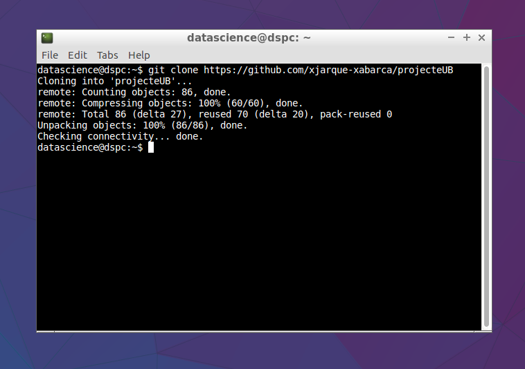

Cargar el proyecto en RStudio:

[figure not shown]

Descargar Python (miniconda) del siguiente enlace:

[Descargar miniconda](https://conda.io/miniconda.html)

[figure not shown]

Instalar miniconda ejecutando el fichero *Miniconda3-latest-Linux-x86.sh*

[figure not shown]

Instalar las librerías de Python necesarias:

```
datascience@dspc:~/miniconda3/bin$ ./conda install pandas scikit-learn matplotlib seaborn
```

[figure not shown]

Instalar las librerias de R necesarias para ejecutar el proyecto. Fichero *install.R*:

[figure not shown]

Abrir el fichero *ui.R* o *server.R* y ejectuar **Run App**:

[figure not shown]

A continuació se abrirá una ventana con la aplicación en ejecución. Seleccione una de al siguientes opciones:

- Inicio | Manual de usuario
- Carga de datos
- Análisis exploratorio (EDA)
- Aprendizaje automático
- Documentación | Manual de instalación

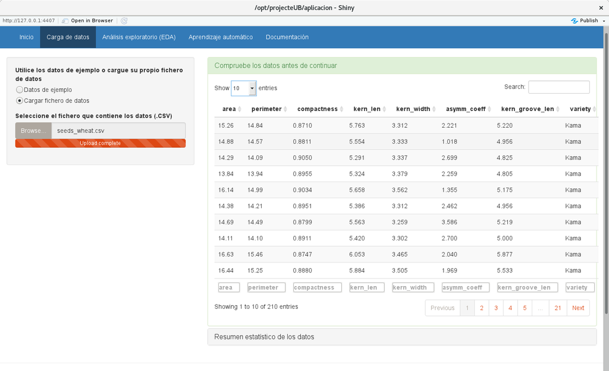

## Decargar máquina virtual para Oracle Virtual Box

Está disponible un máquina virtual con los fuentes de la aplicación y el software necesario para ejectuarla en la siguiente dirección:

[Descargar la máquina virtual con el proyecto instalado](https://drive.google.com/open?id=1DemQ3KpMdalgsH47E_3vDAi8U3zDq0kV)

Una vez descargada importela desde *Oracle Virtual Box*

[figure not shown]

[figure not shown]